# Project 1

2023-02-22

# Project 1 Report: How do players win?

## Introduction

The two datasets chosen for this project represent data for NBA players for the 2021-22 regular season. The `pergame` dataset provides per game data on various variables, such as points per game and minutes played per game. The `advancedstats` dataset provides various advanced metrics for players, such as usage rate and win shares.

Both datasets were acquired from “Basketball Reference”, a website that collects and sorts data from different basketball leagues and teams. Here are the links to where the datasets were obtained from.

https://www.basketball-reference.com/leagues/NBA_2022_per_game.html#per_game_stats https://www.basketball-reference.com/leagues/NBA_2022_advanced.html#advanced_stats

These datasets were chosen because I am an avid NBA fan and I wanted to see if there were certain statistics that correlated to being a better basketball (more specifically, NBA) player.

```r
# calls libraries needed for the project
library(readr)
library(tidyverse)
# NBA data for the 2021 - 2022 season
pergame <- read_csv("/home/ssm3484/SDS322E/Project1/pergamedata.txt")
advancedstats <- read_csv("/home/ssm3484/SDS322E/Project1/advancedstatsdata.txt")
```

```
## ──────────────────────────────────────────────────────── Delimiter: "," chr
## (4): Player, Pos, Tm, Player-additional dbl (24): Rk, Age, G, MP, PER, TS%,
## 3PAr, FTr, ORB%, DRB%, TRB%, AST%, STL%,... lgl (2): ...20, ...25
```

Each row in both datasets represent a NBA player that played minutes during the 2021-22 regular season. We can join the datasets together by common keys/variables such as “Rk”, “Player”, “Pos”, “Age”, “Tm”, “G”, “Player-additional”. The datasets contain mostly numerical variables, with categorical variables only listing information about the player’s name and what position they play.

I expect certain trends to stand out between variables including playing more minutes and scoring more points correlating to greater win shares for each player.

The research question I will be answering is how do certain variables/statistics affect the win shares awarded to each player (WS)? In other words, what statistics in a player allow for their team to win more?

## Joining/Merging Datasets

```r
# joins the two datasets together; removing the 2 empty columns from the second dataset; differentiate between minutes played per game and total in a season
NBA <- left_join(pergame, advancedstats, by = c("Rk", "Player", "Pos", "Age", "Tm", "G", "Player-additional"), suffix = c(".game", ".total")) %>%
  select(!"...20" & !"...25")
head(NBA)
```

```
## # A tibble: 6 × 52
##      Rk Player     Pos     Age Tm        G    GS MP.game    FG   FGA `FG%`  `3P`
##   <dbl> <chr>      <chr> <dbl> <chr> <dbl> <dbl>   <dbl> <dbl> <dbl> <dbl> <dbl>
## 1     1 Precious … C        22 TOR      73    28    23.6   3.6   8.3 0.439   0.8
## 2     2 Steven Ad… C        28 MEM      76    75    26.3   2.8   5.1 0.547   0
## 3     3 Bam Adeba… C        24 MIA      56    56    32.6   7.3  13   0.557   0
## 4     4 Santi Ald… PF       21 MEM      32     0    11.3   1.7   4.1 0.402   0.2
## 5     5 LaMarcus … C        36 BRK      47    12    22.3   5.4   9.7 0.55    0.3
## 6     6 Nickeil A… SG       23 TOT      65    21    22.6   3.9  10.5 0.372   1.6
## # … with 40 more variables: `3PA` <dbl>, `3P%` <dbl>, `2P` <dbl>, `2PA` <dbl>,
## #   `2P%` <dbl>, `eFG%` <dbl>, FT <dbl>, FTA <dbl>, `FT%` <dbl>, ORB <dbl>,
## #   DRB <dbl>, TRB <dbl>, AST <dbl>, STL <dbl>, BLK <dbl>, TOV <dbl>, PF <dbl>,
## #   PTS <dbl>, `Player-additional` <chr>, MP.total <dbl>, PER <dbl>,
## #   `TS%` <dbl>, `3PAr` <dbl>, FTr <dbl>, `ORB%` <dbl>, `DRB%` <dbl>,
## #   `TRB%` <dbl>, `AST%` <dbl>, `STL%` <dbl>, `BLK%` <dbl>, `TOV%` <dbl>,
## #   `USG%` <dbl>, OWS <dbl>, DWS <dbl>, WS <dbl>, `WS/48` <dbl>, OBPM <dbl>, …
```

I joined the datasets on variables common to each dataset, as listed above. I used left join, but it didn’t seem to matter what join function was used as the number of observations stayed the same. Suffixes were also added to differentiate between the minutes player variables (both per game and season total). I also noticed that there were 2 empty columns in the `advancedstats` dataset due to extra commas in the text file; therefore I removed them using the “select” dplyr function.

There were 605 observations in each dataset before joining, 24 IDs in the `pergame` dataset that were not in the other, 21 IDs (not including empty columns) in the `advancedstats` dataset that were not in `pergame`, 7 IDs in common between the datasets.

There were no observations that were dropped/added after joining, but there were 2 empty columns that were dropped, as mentioned earlier.

## Wrangling / Some Tidying

```r
# wrangles a new dataset to include only high-performing players and significant variables that affect player's winning ability
NBAfinal <- NBA %>%
  select(Player, Tm, Pos, PTS, MP.game, TOV, "TS%", "USG%", WS) %>%
  filter(PTS > 10) %>%
  mutate(star = ifelse(PTS > 20, "TRUE", "FALSE")) %>%
  arrange(desc(star))
# defines new variable to determine whether player is a star or not
mutateStars <- NBA %>%
  filter(PTS > 10) %>%
  mutate(star = ifelse(PTS > 20, "TRUE", "FALSE")) %>%
  group_by(star) %>%
  summarize(nstar = n())
head(NBAfinal)
```

```
## # A tibble: 6 × 10
##   Player                Tm    Pos     PTS MP.game   TOV `TS%` `USG%`    WS star
##   <chr>                 <chr> <chr> <dbl>   <dbl> <dbl> <dbl>  <dbl> <dbl> <chr>
## 1 Giannis Antetokounmpo MIL   PF     29.9    32.9   3.3 0.633   34.9  12.9 TRUE
## 2 LaMelo Ball           CHO   PG     20.1    32.3   3.3 0.554   28.2   5.8 TRUE
## 3 Bradley Beal          WAS   SG     23.2    36     3.4 0.539   30.8   1.4 TRUE
## 4 Devin Booker          PHO   SG     26.8    34.5   2.4 0.576   32     7.6 TRUE
## 5 Miles Bridges         CHO   PF     20.2    35.5   1.9 0.593   22.6   7.2 TRUE
## 6 Jaylen Brown          BOS   SF     23.6    33.6   2.7 0.574   30.5   5.8 TRUE
```

```r
mutateStars
```

```
## # A tibble: 2 × 2
##   star  nstar
##   <chr> <int>
## 1 FALSE   144
## 2 TRUE     39
```

The dataset was filtered to only include players that averaged 10 points per game during the season. This was done to only include players that have significant impacts on their teams and the games themselves.

To be considered a “star” in the NBA, scoring 20 points per game is the bare minimum to achieve such status, so a categorical variable was created to distinguish between “stars” and “non-stars”. Additionally, the number of “stars” was calculated as well.

```r
# summary stats for PTS, WS, and Pos
summary(NBAfinal$PTS)
```

```
##    Min. 1st Qu.  Median    Mean 3rd Qu.    Max.
##   10.10   11.80   15.00   16.07   18.70   30.60
```

```r
summary(NBAfinal$WS)
```

```
##    Min. 1st Qu.  Median    Mean 3rd Qu.    Max.
##  -1.600   1.950   3.700   4.179   6.000  15.200
```

```r
freqPOS <- table(NBAfinal$Pos)
prop.table(freqPOS)
```

```
##
##           C          PF        PF-C          PG       PG-SG          SF
## 0.142076503 0.185792350 0.005464481 0.218579235 0.005464481 0.147540984
##       SF-SG          SG       SG-PG
## 0.010928962 0.273224044 0.010928962
```

After computing summary statistics, of the high performance players, the mean number of points scored per game (averaged over 82 games) was 16.07 points, with the greatest average PPG being 30.60 points. The mean number of WS (win shares) was 4.179, meaning the average high-performing player contributed to around 4 wins for his team for the entire season (This stat shows how valuable a player is to a team’s success).

When looking at the types of positions played, shooting guards (SG) contributed to the largest proportion of players who scored 10 points or more in the league, with 27.32%. The very small proportions correspond to the few players who are listed as playing multiple positions for their teams.

```r
# using tidyr functions
mutateStars %>% pivot_wider(names_from = star, values_from = nstar, values_fn = list(nstar = mean))
```

```
## # A tibble: 1 × 2
##   `FALSE` `TRUE`
##     <dbl>  <dbl>
## 1     144     39
```

Since the dataset was already tidy before and after merging, I used the pivot_wider function to rearrange “mutateStars” and make it less cluttered with only two labels, “TRUE” and “FALSE”. This depicts how many high-performing players are “stars” or not.

## Visualizations

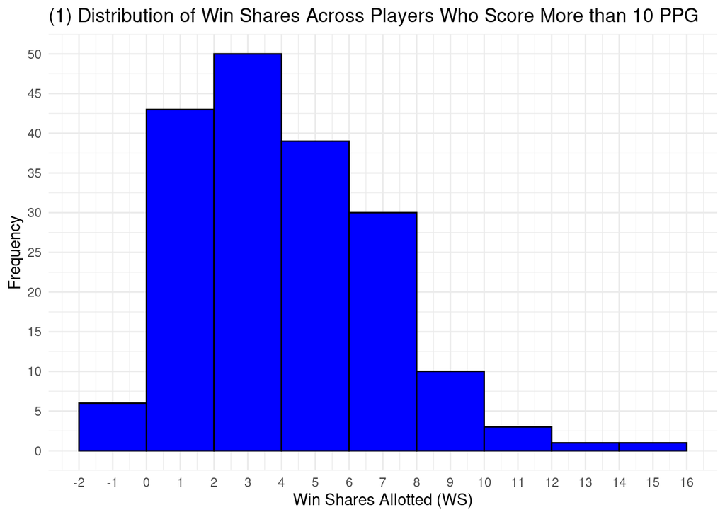

```r
# Visualization 1; displays the distribution of win shares across impactful players
ggplot(NBAfinal, aes(x = WS)) +
  geom_histogram(binwidth = 2, center = -1, fill = "blue", color = "black") +
  scale_x_continuous(breaks = seq(-2, 16, 1)) +
  scale_y_continuous(breaks = seq(0, 55, 5)) +
  labs(title = "(1) Distribution of Win Shares Across Players Who Score More than 10 PPG",
       x = "Win Shares Allotted (WS)",
       y = "Frequency") +
  theme_minimal()
```

The plot depicts the amount of win shares allotted to players that score more 10 points per game in the regular season. The trends show that majority of these players have win shares between 0 and 8 for each their respective teams. This means that, on average, a player will be contributing to 0-8 wins for his team.

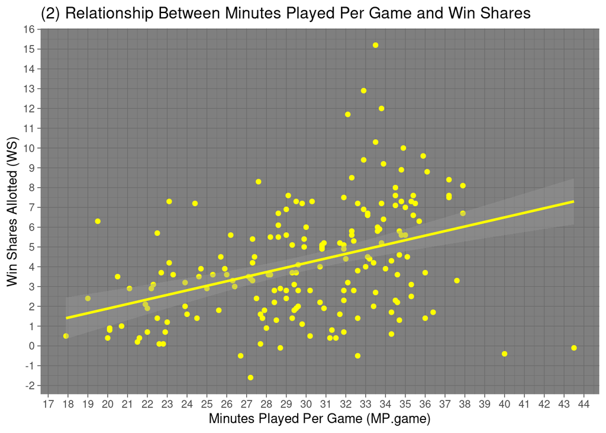

```r
# Visualization 2; displays relationship between MP per game and WS
ggplot(NBAfinal, aes(x = MP.game, y = WS)) +
  geom_point(color = "yellow") +
  labs(title = "(2) Relationship Between Minutes Played Per Game and Win Shares",
       x = "Minutes Played Per Game (MP.game)",
       y = "Win Shares Allotted (WS)") +
  stat_smooth(method = "lm",
              formula = y ~ x,
              geom = "smooth",
              color = "yellow") +
  scale_y_continuous(breaks = seq(-2, 16, 1)) +
  scale_x_continuous(breaks = seq(17, 45, 1)) +
  theme_dark()
```

The plot represents the relationship between the number of minutes a player is on the court and how many win shares he receives for the season. There seems to be a positive correlation between minutes played per game and win shares received. This can predict that playing more minutes per game will, generally, increase WS (based on correlation, not causation).

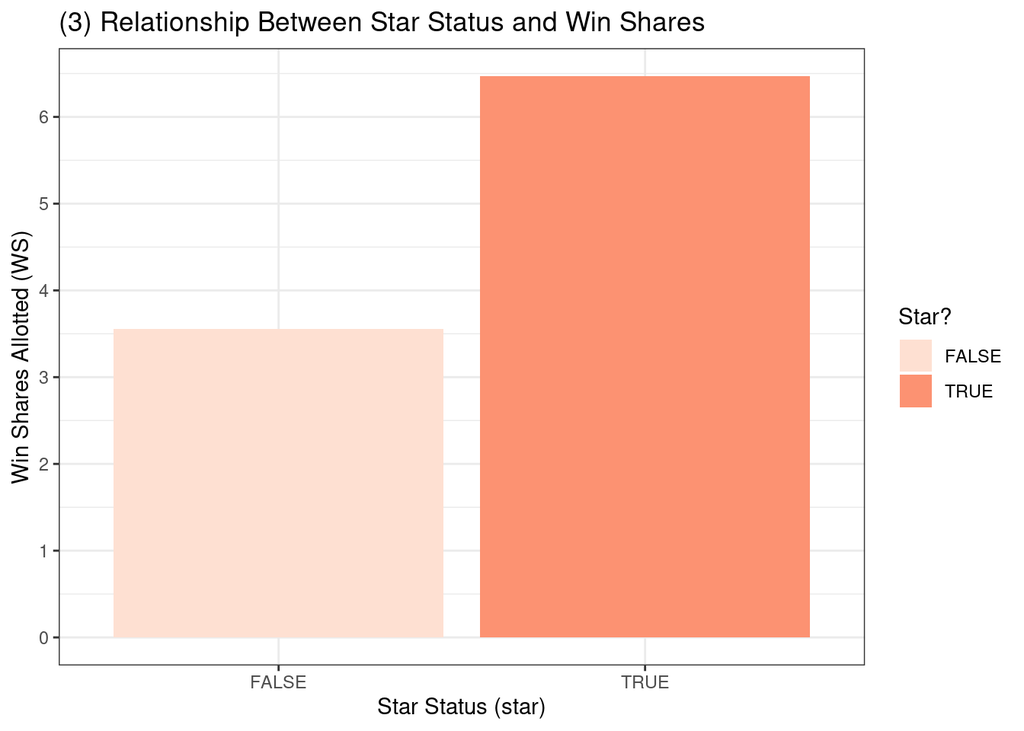

```r
# Visualization 3; shows how star status affects win shares for players
ggplot(NBAfinal, aes(x = star, y = WS, fill = star)) +
  geom_bar(stat = "summary", fun = "mean") +
  theme_bw() +
  scale_fill_brewer(palette = "Reds") +
  scale_y_continuous(breaks = seq(0, 8, 1)) +
  labs(title = "(3) Relationship Between Star Status and Win Shares",
       fill = "Star?",
       x = "Star Status (star)",
       y = "Win Shares Allotted (WS)")
```

This plot shows how the mean number of win shares differs between players who score less than or equal to 20 points and players who score more than 20 points per game (not a star v.s. star). The plot depicts that “star” players have, on average, 3 more win shares than “non-star” players. This shows that players who score more points receive more win shares for the season.

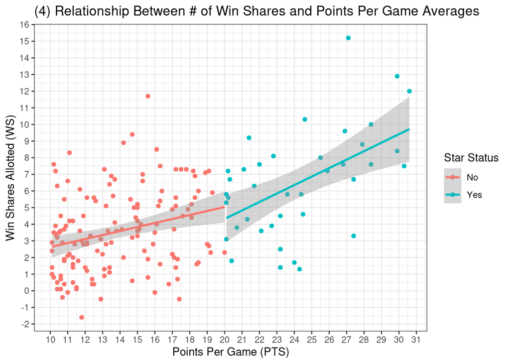

```r
# Visualization 4; displays regression lines for the relationship between WS and PTS based on whether player is a "star" or not
ggplot(NBAfinal, aes(x = PTS, y = WS, color = star)) +
  geom_point() +
  labs(title = "(4) Relationship Between # of Win Shares and Points Per Game Averages",
       color = "Star Status",
       x = "Points Per Game (PTS)",
       y = "Win Shares Allotted (WS)") +
  scale_color_discrete(labels = c('No', 'Yes')) +
  scale_y_continuous(breaks = seq(-2, 16, 1)) +
  scale_x_continuous(breaks = seq(10, 31, 1)) +
  stat_smooth(method = "lm",
              formula = y ~ x,
              geom = "smooth") +
  theme_bw()
```

The plot depicts the relationship of how many points a player scores per game and the number of win shares allotted to him, while differentiating between star status (20 points per game scorer or not). There seems to be a positive relationship between PTS and WS, but star players or higher scorers seems to receive more win shares for each additional point scored past 20 (greater slope). The same conclusion can be drawn as in (3); more points leads to more win shares allotted.

## Discussion

When answering the research question based on our previous findings, I believe that more minutes played and points scored per game leads to player having more win shares, ultimately, giving his team more wins. Based on (2) and (4), there is a positive correlation between win shares and minutes played/points scored, respectively. Considering that the mean WS across impactful players is around 4, I believe that this value is justified through star players scoring more and playing more minutes.

In formulating this project, I found it difficult to choose which variables I would compare when showing potential relationships with win shares. I ended up choosing PTS and MP.game as they seemed the easiest to understand for readers. But I believe that using other variables such as USG% and TS% would have provided similar conclusions. If I could have added more visualizations, I would have used USG% and TS% to further show the relationship with win shares and what characteristics allow a player/team to win more.

*Acknowledgments: BasketballReference for the datasets and StackOverflow for technical programming questions*